# Lab 5

David Wilson • dwils152@unc.edu

3/17/2022

#### 1) This question uses data from this paper: https://science.sciencemag.org/content/347/6217/78.

##### *Variation in cancer risk among tissues can be explained by the number of stem cell divisions. Science 02 Jan 2015: Vol. 347, Issue 6217, pp. 78-81*

##### a) Download the data from here examining the relationship between the number of cell divisions and cancer risk: https://fodorclasses.github.io/classes/stats2020/cancerRisk.txt On a log10-log10 scale graph Lifetime_cancer_risk (on the y-axis) vs. CumulativeCellDivisions (on the x-axis). This reproduces Fig. 1 from the paper. You can read in the file with read.table(“cancerRisk.txt”, header=TRUE, sep=")

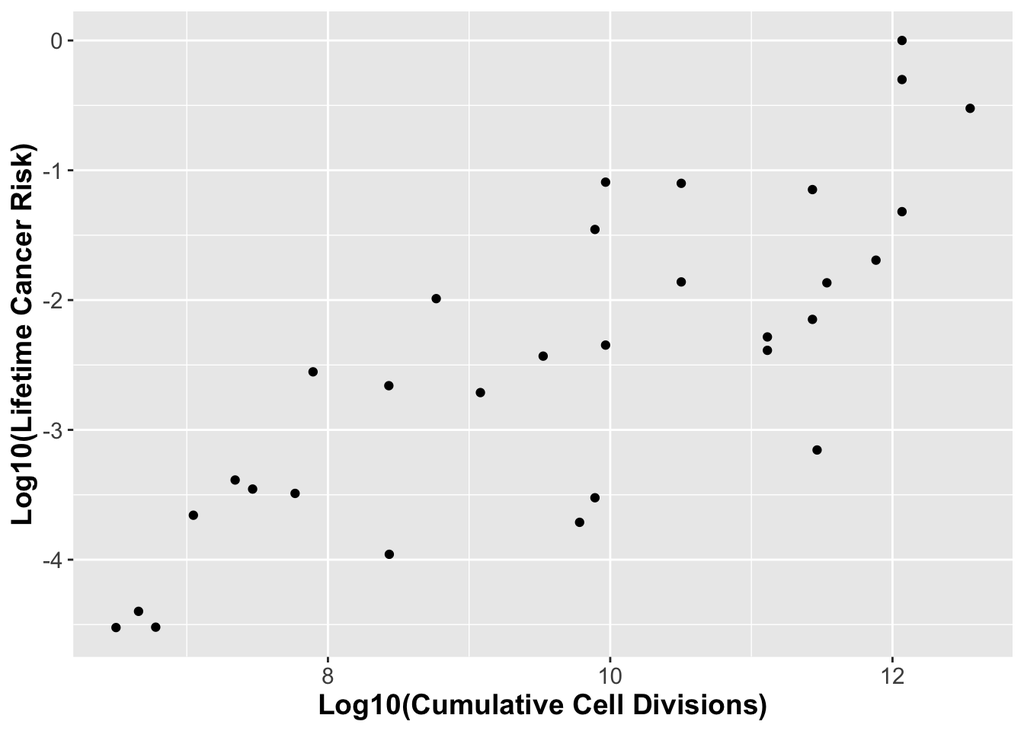

```r
library(ggplot2)
library(ggrepel)
library(ggthemes)

cancer_risk <- read.table('cancerRisk.txt', header=TRUE, sep='\t')

plot <- ggplot(cancer_risk, aes(x=log10(CumulativeCellDivisions), y=log10(Lifetime_cancer_risk))) +
         geom_point() + theme(text=element_text(size=14), axis.title.x=element_text(face="bold"), axis.title.y=element_text(face="bold")) +
         xlab("Log10(Cumulative Cell Divisions)") + ylab("Log10(Lifetime Cancer Risk)") #+ geom_label_repel(aes(label=Cancer_type), size=1.5)

plot
```

##### b) Using the lm function, fit a linear model with Lifetime_cancer_risk as the Y variable and CumulativeCellDivisions as the x-data. Add the regression line to the plot using the function abline(myLm), where myLm is the linear model you created.

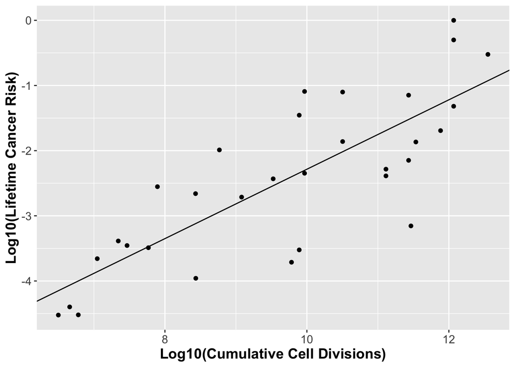

```r
risk <- log10(cancer_risk$Lifetime_cancer_risk)
cell_div <- log10(cancer_risk$CumulativeCellDivisions)

myLm <- lm(risk ~ cell_div)
slope <- myLm$coefficients[[2]]
intercept <- myLm$coefficients[[1]]

plot + geom_abline(slope=slope, intercept=intercept)
```

##### c) What is the p-value for the null hypothesis that the slope of the regression between these two variables is zero? What is the r-squared value of the model?

```r
summary(myLm)
```

```
##
## Call:
## lm(formula = risk ~ cell_div)
##
## Residuals:
##      Min       1Q   Median       3Q      Max
## -1.65115 -0.46564  0.06167  0.43180  1.21040
##
## Coefficients:
##             Estimate Std. Error t value Pr(>|t|)
## (Intercept) -7.61081    0.72292 -10.528 2.03e-11 ***
## cell_div     0.53264    0.07317   7.279 5.12e-08 ***
## ---
## Signif. codes:  0 '***' 0.001 '**' 0.01 '*' 0.05 '.' 0.1 ' ' 1
##
## Residual standard error: 0.7491 on 29 degrees of freedom
## Multiple R-squared:  0.6463, Adjusted R-squared:  0.6341
## F-statistic: 52.99 on 1 and 29 DF,  p-value: 5.124e-08
```

##### d): Are the assumptions of constant variance and normal distribution of the residues reasonable for this model? Justify your answer.

Since we don’t have multiple sample’s for each x-value, the best we can do is plot the residuals. Visual assessment of the Q-Q plot for residuals shows that they are normally distributed. To assess variance we can plot the residuals vs. our linear model. This plot shows that there are a few outliers (points, 17, 27, and 28) but the variance is rougly equal

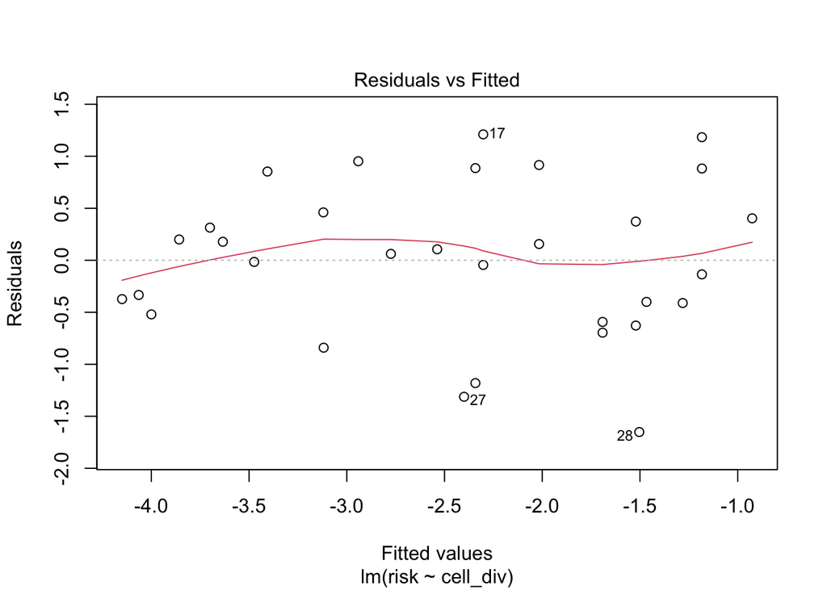

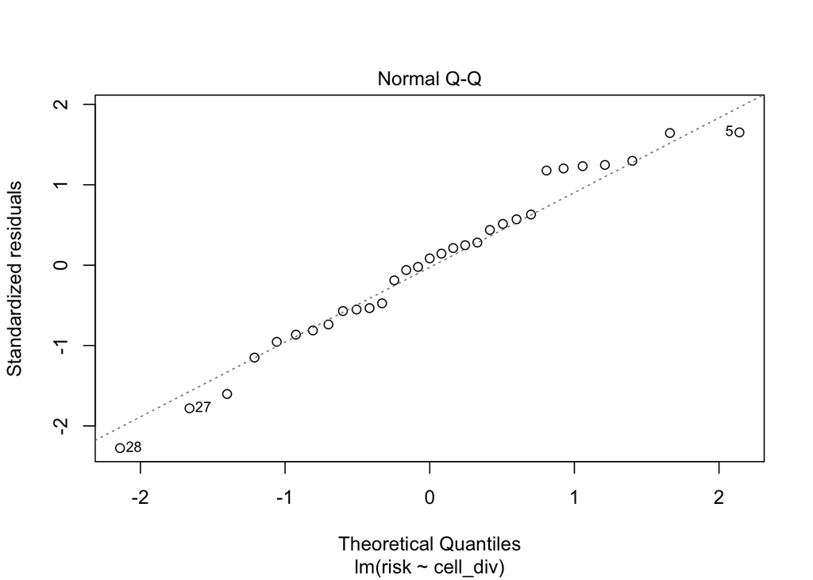

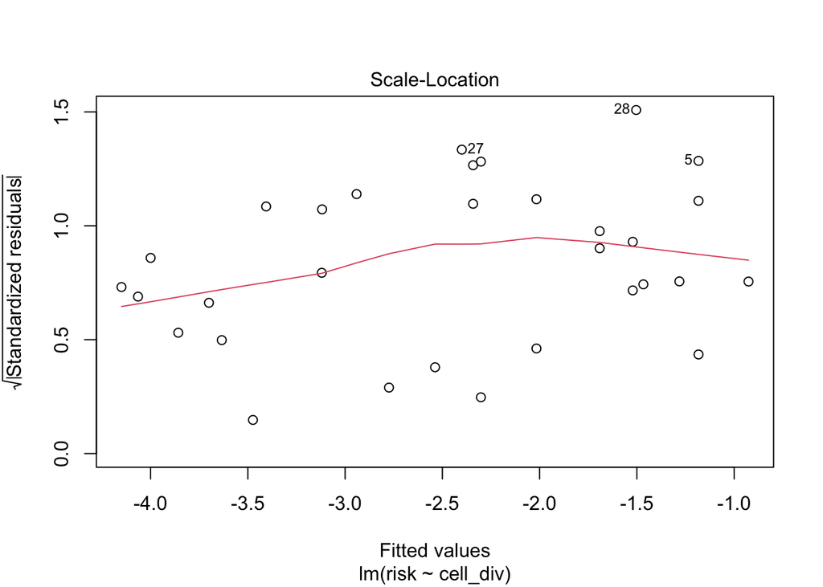

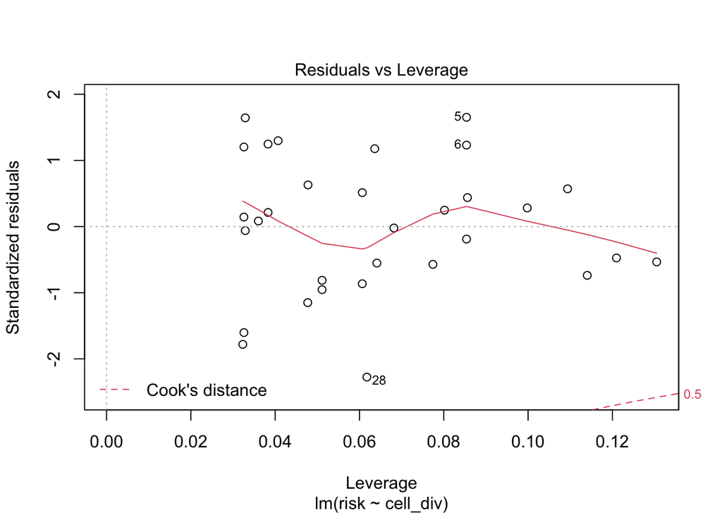

```r
plot(myLm)
```

#### 2) Consider the case-control file for the colorectal adenomas data set that is here: http://afodor.github.io/classes/stats2015/caseControlData.txt. A separate file gives obesity (BMI) data for these same subjects:http://afodor.github.io/classes/stats2015/BMI_Data.txt.

##### a) For each OTU in the spreadsheet, generate a p-value from linear regression comparing BMI to the relative abundance of each OTU. Graph out all the p-values.

```r
library(tidyr)
library(dplyr)
bmi <- read.table('BMI_data.txt', header=TRUE, sep='\t')
case_control <- read.table('caseControlData.txt', header=TRUE, sep='\t')

#split the case_control sample_id so it can be merged with bmi
cases <- separate(case_control, col=sample, into=c('sample_id', 'case_id'), sep='_', extra='merge')

#there are 71 unique samples in the cases tables and 165 unique samples in the bmi table
#this means we'll have some missing data when we merge the tables
merged <- merge(cases, bmi, by.x='sample_id', by.y='studyid')

#dropping unnecessary cols, moving bmi into 1st column, and drop columns that contain NA
merged$sample_id <- NULL
merged$case_id <- NULL
merged <- merged %>% relocate(bmi)
merged <- merged %>% drop_na()
```

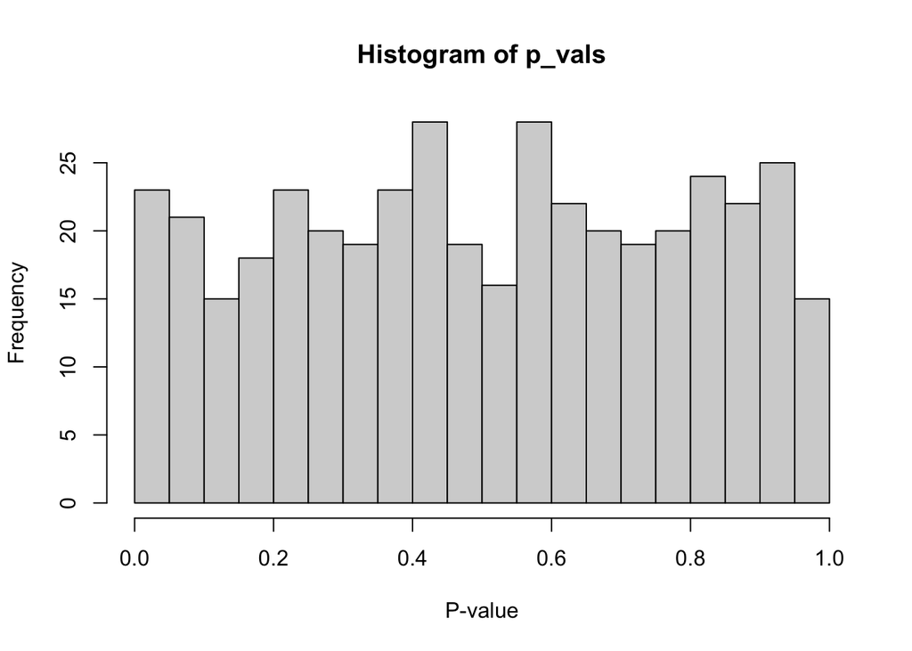

```r
p_vals <- vector(length=(ncol(merged)-1))

for ( i in 2:ncol(merged) ) {

  model <- lm(data=merged, bmi ~ merged[,i])
  p_vals[i-1] <- anova(model)$"Pr(>F)"[1]

}

hist(p_vals, breaks = 15, xlab='P-value')
```

##### Do they appear uniformly distributed? Does the microbial community appear to be influencing body weight in this cohort? Are any of these associations significant at a 10% false discovery rate? Hints: To lookup the ids in the BMI table, you will need to some processing on the “sample” column in the caseControl file. The following code will convert the a sampleID so that it will match the BMI file.# remove case and control key <- sub(“case”, "“, sampleID) key <- sub(”control“,”“, key) # remove extraneous information from the suffix key <- strsplit( key,”_")[[1]][1]

```r
adj_p_vals <- p.adjust(p_vals, method="BH")
adj_p_vals_fdr10 <- adj_p_vals[adj_p_vals <= 0.10]
```

Yes, the data appear uniformly distributed. It appears that none the the OTUs have a significant influence on BMI at a 10% FDR